# Instance results

2025-04-29

This report contains different plots and tables that may be relevant for analyzing the results. Given a problem consisting of $m$ subproblems with $Y_N^s$ given for each subproblem $s$, we use a filtering algorithm to find $Y_N$.

The following instance/problem groups are generated given:

- $p=2,\ldots, 5$.
- $S=2,\ldots 5$ where $S$ is the number of subproblems.
- All subproblems have the same method config or half have method `u` and `l`.
- Five instances for each config.

1280 problems have been solved.

## 1 Size of $Y_N$

What is $|Y_N|$ given the different methods of generating the set of nondominated points for the subproblems?

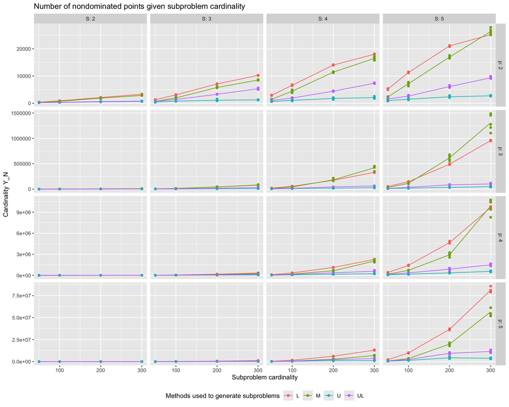

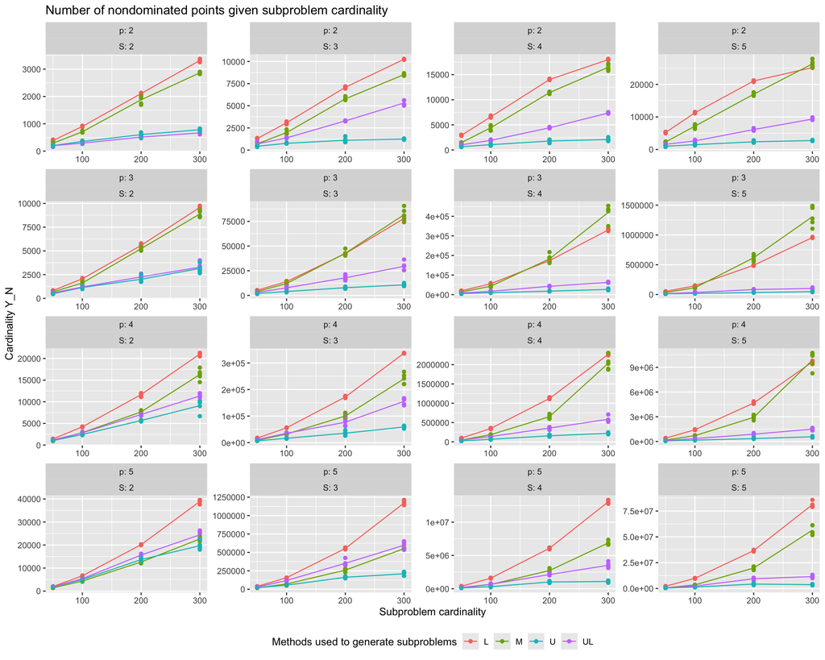

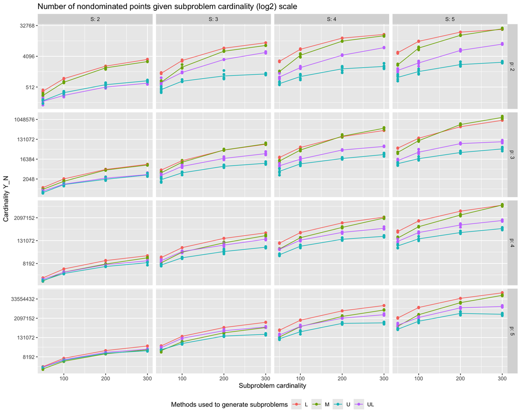

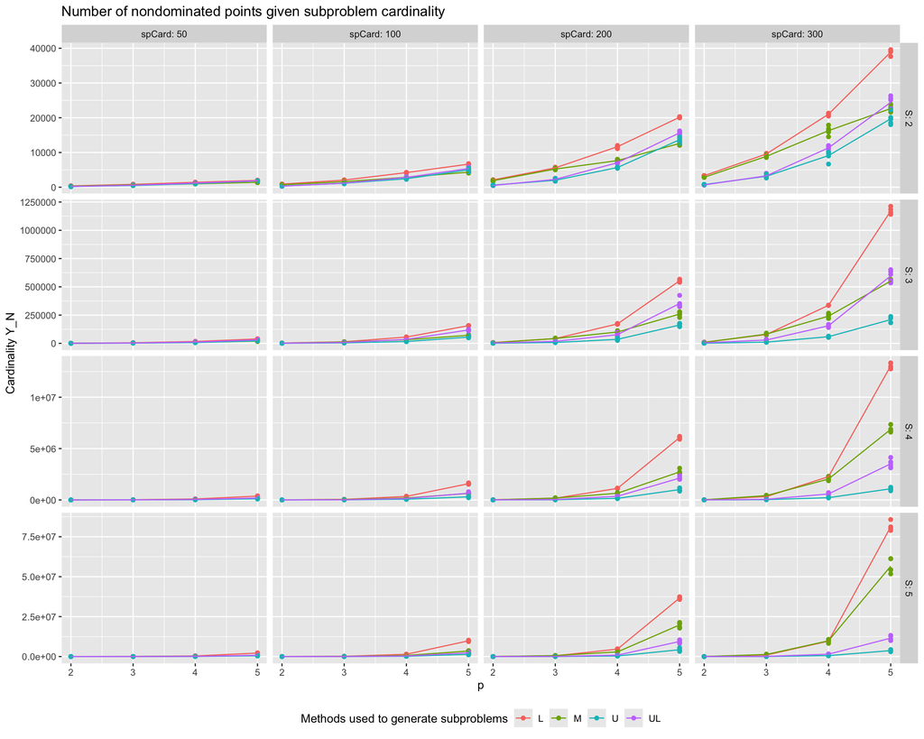

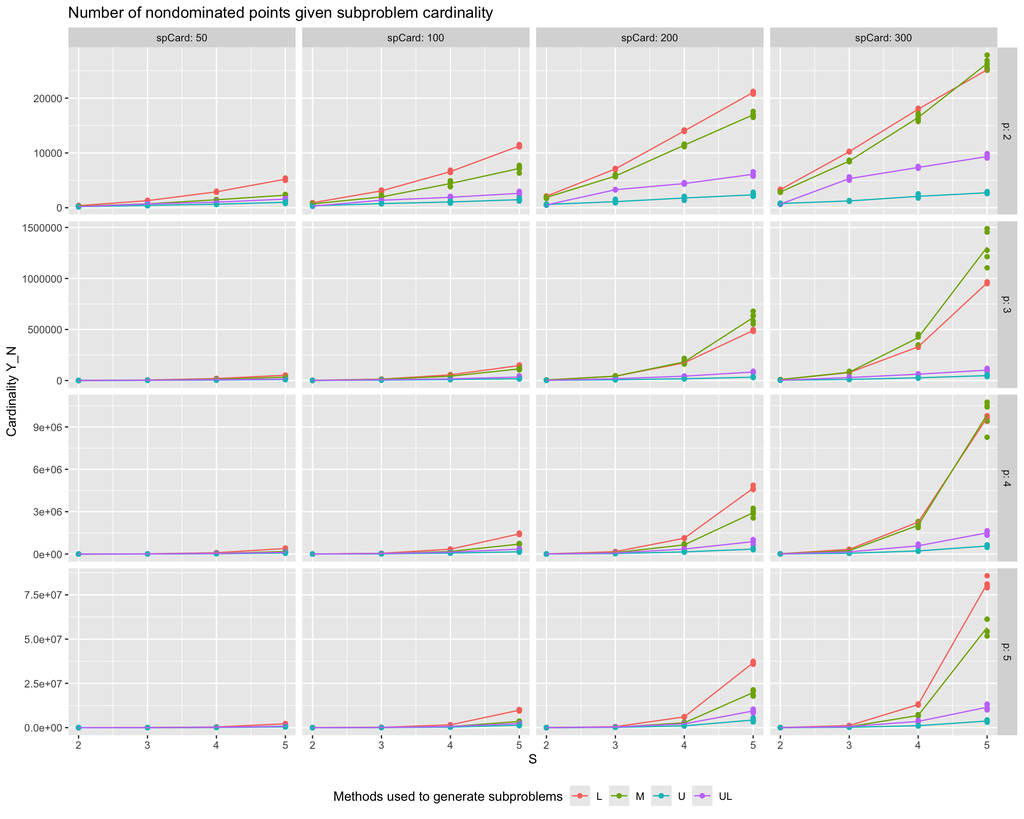

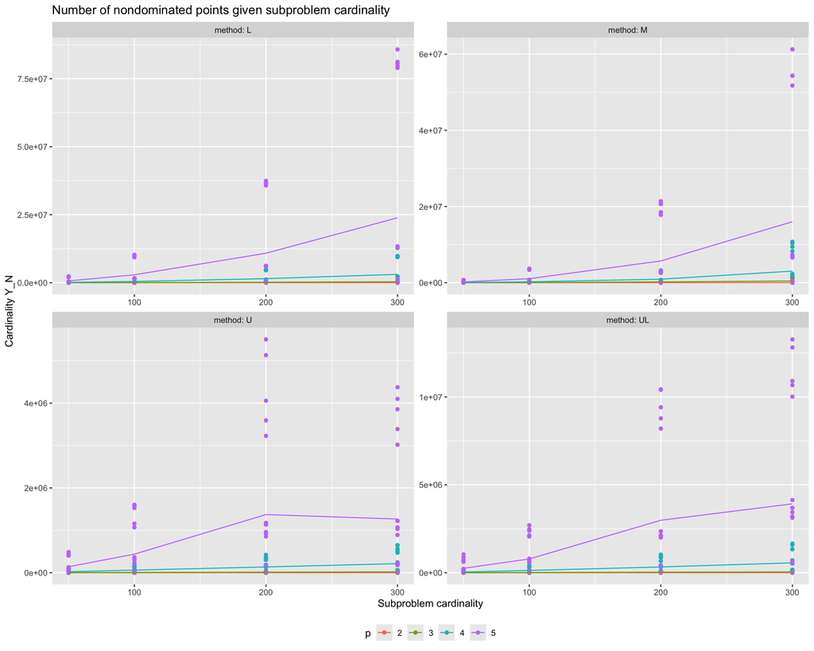

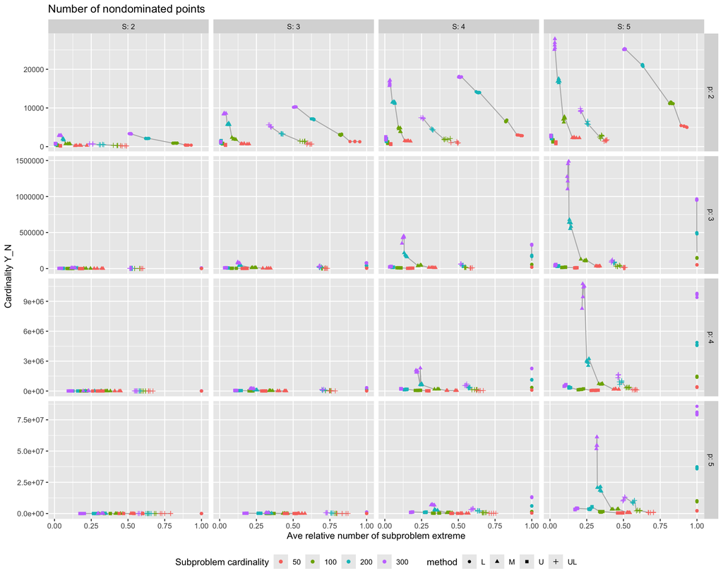

### 1.1 Summary tables

Below summary tables with summary results for different aggregation levels are given (`card = |Y_N|`).

|  | method | min_card | mean_card | max_card | instances |
| --- | --- | --- | --- | --- | --- |
| 1 | L | 367 | 2751741.35 | 85791330 | 320 |
| 2 | M | 237 | 1748350.996875 | 61256072 | 320 |
| 3 | U | 168 | 232167.465625 | 5501638 | 320 |
| 4 | UL | 151 | 570671.815625 | 13267366 | 320 |

|  | method | S | p | min_card | mean_card | max_card | instances |
| --- | --- | --- | --- | --- | --- | --- | --- |
| 1 | L | 2 | 2 | 367 | 1678.15 | 3379 | 20 |
| 2 | L | 2 | 3 | 794 | 4512.8 | 9745 | 20 |
| 3 | L | 2 | 4 | 1402 | 9580.05 | 21295 | 20 |
| 4 | L | 2 | 5 | 1902 | 16921.35 | 39600 | 20 |
| 5 | L | 3 | 2 | 1259 | 5427.55 | 10306 | 20 |
| 6 | L | 3 | 3 | 5147 | 34866.1 | 80759 | 20 |
| 7 | L | 3 | 4 | 15601 | 145325.95 | 338187 | 20 |
| 8 | L | 3 | 5 | 37513 | 479915.5 | 1212454 | 20 |
| 9 | L | 4 | 2 | 2822 | 10380.15 | 18161 | 20 |
| 10 | L | 4 | 3 | 18665 | 144763.55 | 336519 | 20 |

[output cut: 54 more lines]

|  | method | S | p | spCard | min_card | mean_card | max_card | instances |
| --- | --- | --- | --- | --- | --- | --- | --- | --- |
| 1 | L | 2 | 2 | 50 | 367 | 385.8 | 422 | 5 |
| 2 | L | 2 | 2 | 100 | 883 | 903 | 927 | 5 |
| 3 | L | 2 | 2 | 200 | 2072 | 2106.6 | 2135 | 5 |
| 4 | L | 2 | 2 | 300 | 3254 | 3317.2 | 3379 | 5 |
| 5 | L | 2 | 3 | 50 | 794 | 828.6 | 846 | 5 |
| 6 | L | 2 | 3 | 100 | 1994 | 2064.8 | 2144 | 5 |
| 7 | L | 2 | 3 | 200 | 5395 | 5580 | 5795 | 5 |
| 8 | L | 2 | 3 | 300 | 9386 | 9577.8 | 9745 | 5 |
| 9 | L | 2 | 4 | 50 | 1402 | 1424.2 | 1450 | 5 |
| 10 | L | 2 | 4 | 100 | 4085 | 4207.2 | 4286 | 5 |

[output cut: 246 more lines]

### 1.2 Regression fit

Let us try to fit the results using function $y=c_1 s^{(c_2p)} S^{c_3p}$ (different functions was tried and this gave the highest $R^2$) for each method:

```
## # A tibble: 4 × 15
##   method fit    tidied   r.squared adj.r.squared sigma statistic   p.value    df
##   <chr>  <list> <list>       <dbl>         <dbl> <dbl>     <dbl>     <dbl> <dbl>
## 1 L      <lm>   <tibble>     0.867         0.866 1.06      1031. 1.90e-139     2
## 2 M      <lm>   <tibble>     0.802         0.800 1.26       641. 4.46e-112     2
## 3 UL     <lm>   <tibble>     0.923         0.923 0.744     1902. 2.77e-177     2
## 4 U      <lm>   <tibble>     0.954         0.954 0.530     3312. 3.54e-213     2
## # ℹ 6 more variables: logLik <dbl>, AIC <dbl>, BIC <dbl>, deviance <dbl>,
## #   df.residual <int>, nobs <int>
```

```
## # A tibble: 4 × 4
##   method    c1     c2    c3
##   <chr>  <dbl>  <dbl> <dbl>
## 1 L       74.0 0.0870 1.25
## 2 M       71.1 0.0903 1.16
## 3 UL      29.2 0.125  1.09
## 4 U       21.5 0.137  0.974
```

The parameters estimates are:

[interactive chart not shown]

## 2 Relative size of $Y_N$

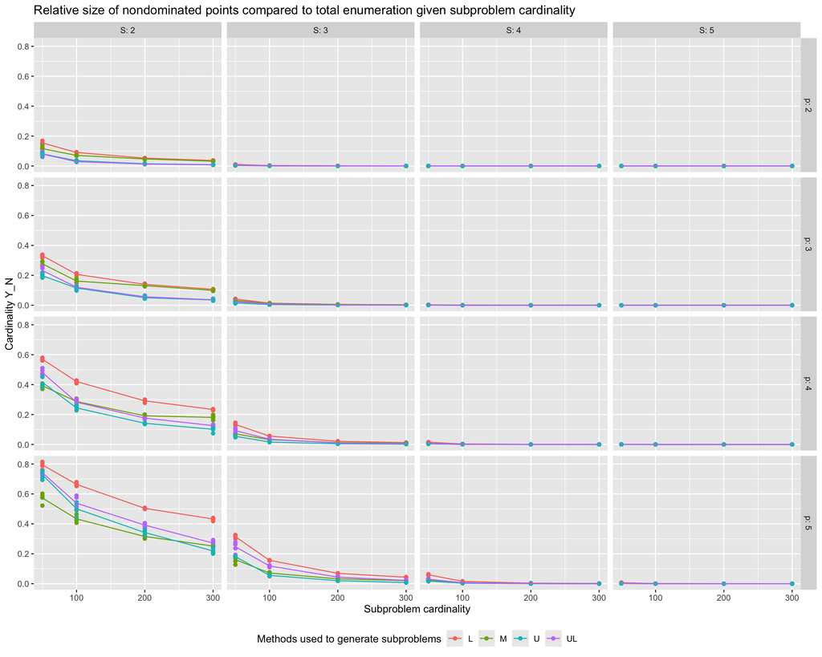

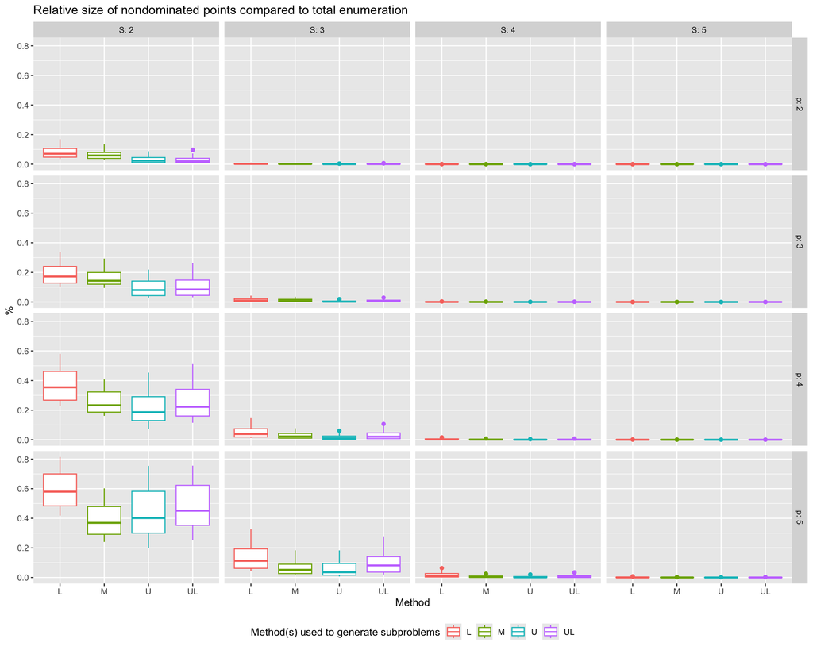

## 3 Nondominated points classification

We classify the nondominated points into, extreme, supported non-extreme and unsupported.

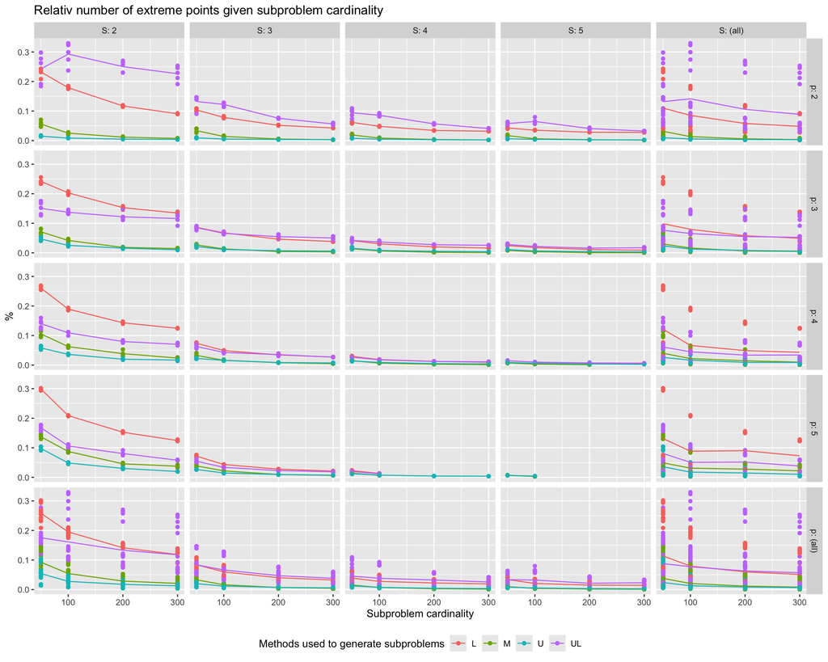

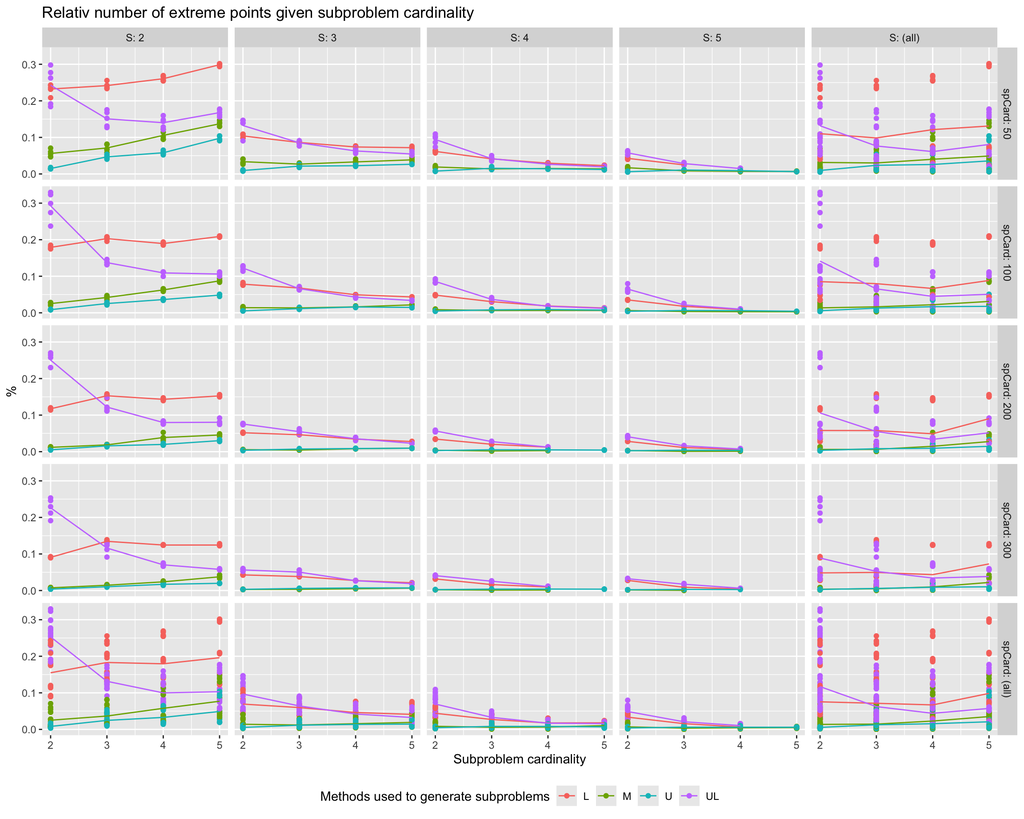

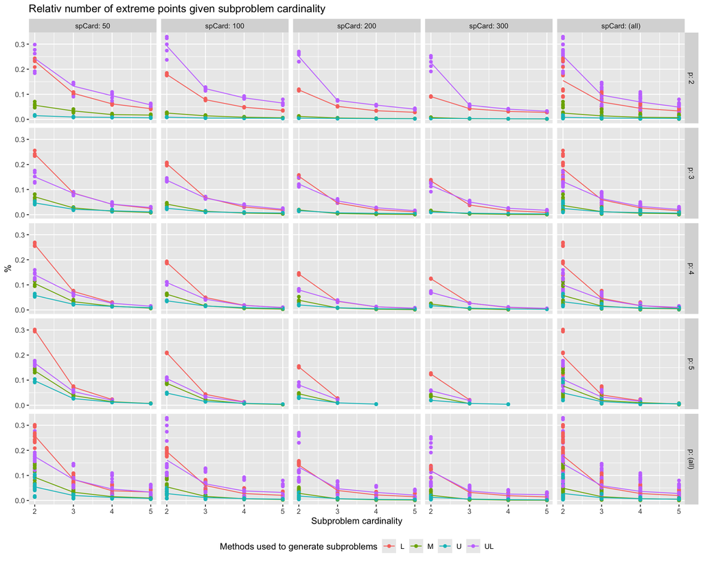

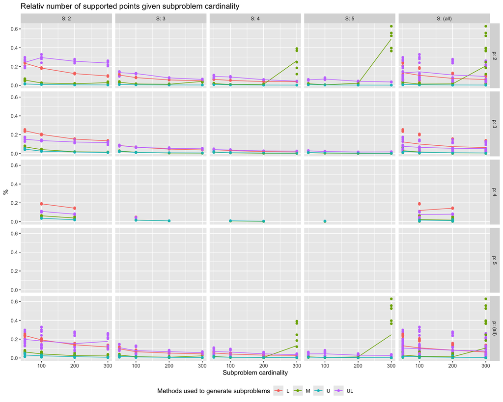

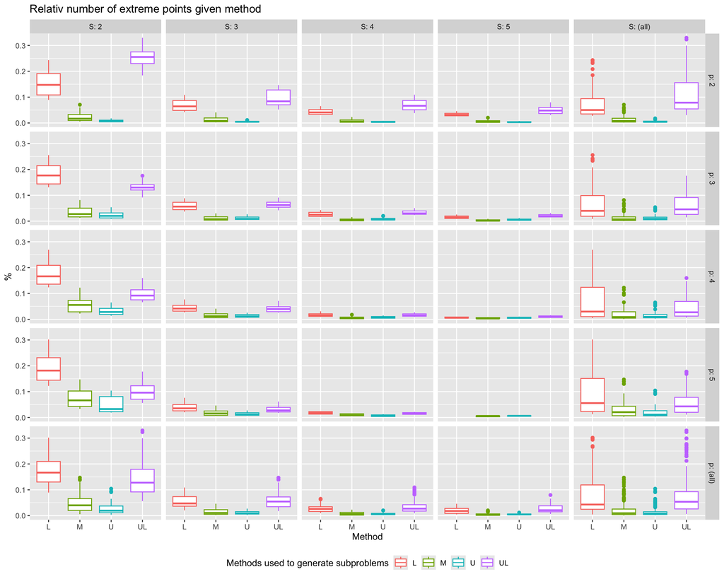

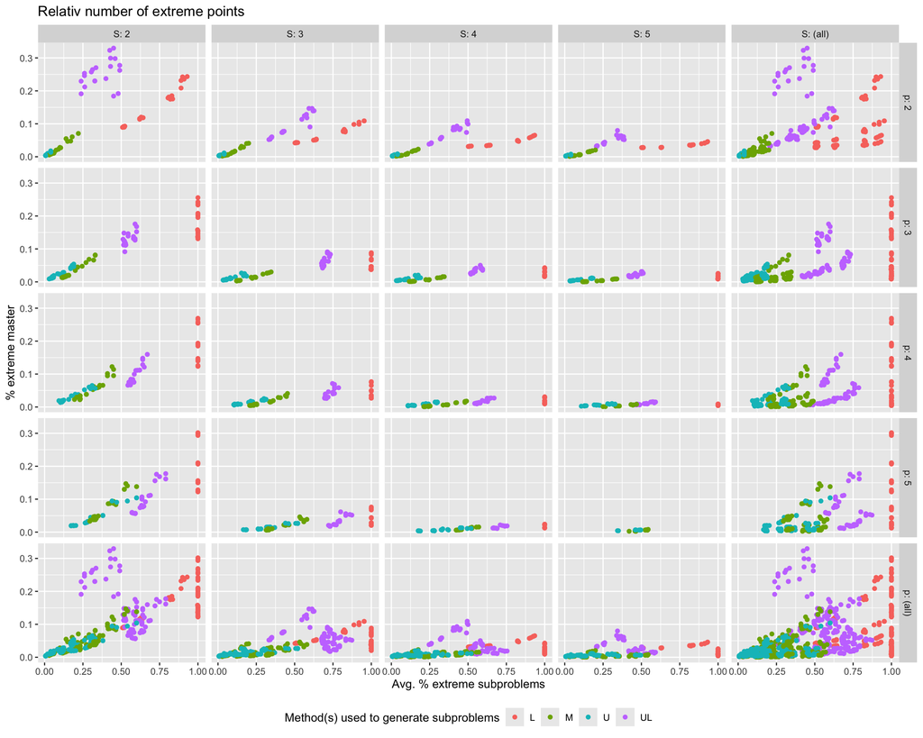

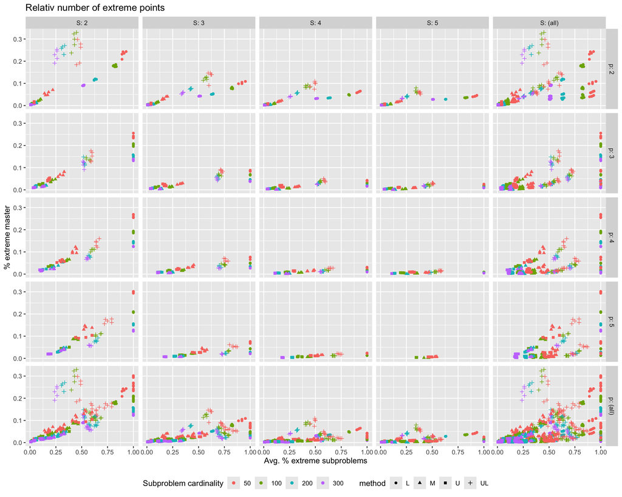

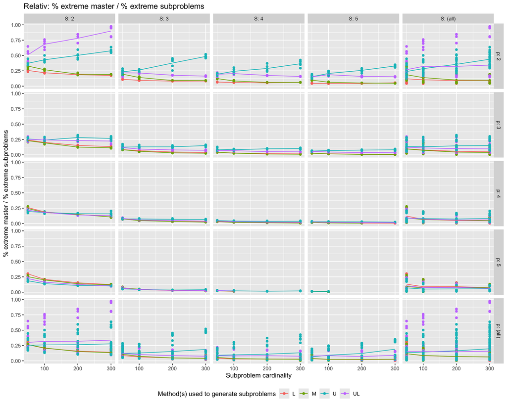

### 3.1 Summary tables

Below summary tables with summary results for different aggregation levels are given. Only instances which have been classified are included.

|  | method | mean_card | mean_sup | mean_pctSup | mean_ext | mean_pctExt | mean_unsup | instances |
| --- | --- | --- | --- | --- | --- | --- | --- | --- |
| 1 | L | 32527.3 | 1098.77 | 0.1 | 1083.53 | 0.09 | 31428.53 | 135 |
| 2 | M | 120122.12 | 767.55 | 0.04 | 299.41 | 0.02 | 119354.57 | 195 |
| 3 | U | 15774.38 | 97.99 | 0.01 | 97.99 | 0.01 | 15676.39 | 190 |
| 4 | UL | 14900.51 | 496.13 | 0.09 | 491.13 | 0.09 | 14404.39 | 175 |

|  | method | S | p | mean_card | mean_sup | mean_pctSup | mean_ext | mean_pctExt | mean_unsup | instances |
| --- | --- | --- | --- | --- | --- | --- | --- | --- | --- | --- |
| 1 | L | 2 | 2 | 1678.15 | 211.8 | 0.16 | 199.8 | 0.15 | 1466.35 | 20 |
| 2 | L | 2 | 3 | 4512.8 | 690.2 | 0.18 | 690.2 | 0.18 | 3822.6 | 20 |
| 3 | L | 2 | 4 | 7933.1 | 1232.8 | 0.17 | 1232.8 | 0.17 | 6700.3 | 10 |
| 4 | L | 3 | 2 | 5427.55 | 325.1 | 0.07 | 295.2 | 0.07 | 5102.45 | 20 |
| 5 | L | 3 | 3 | 34866.1 | 1586.5 | 0.06 | 1586.35 | 0.06 | 33279.6 | 20 |
| 6 | L | 3 | 4 | 55857.8 | 2758.4 | 0.05 | 2758.4 | 0.05 | 53099.4 | 5 |
| 7 | L | 4 | 2 | 10380.15 | 448.65 | 0.05 | 387.95 | 0.04 | 9931.5 | 20 |
| 8 | L | 4 | 3 | 144763.55 | 2848.45 | 0.03 | 2848.3 | 0.03 | 141915.1 | 20 |
| 9 | M | 2 | 2 | 1435.25 | 37.15 | 0.03 | 19.25 | 0.03 | 1398.1 | 20 |
| 10 | M | 2 | 3 | 4107.95 | 85.55 | 0.04 | 85.55 | 0.04 | 4022.4 | 20 |

[output cut: 32 more lines]

|  | method | S | p | spCard | mean_card | mean_sup | mean_pctSup | mean_ext | mean_pctExt | mean_unsup | instances |
| --- | --- | --- | --- | --- | --- | --- | --- | --- | --- | --- | --- |
| 1 | L | 2 | 2 | 50 | 385.8 | 90.4 | 0.23 | 89.4 | 0.23 | 295.4 | 5 |
| 2 | L | 2 | 2 | 100 | 903 | 165.8 | 0.18 | 161.6 | 0.18 | 737.2 | 5 |
| 3 | L | 2 | 2 | 200 | 2106.6 | 262.6 | 0.12 | 247.2 | 0.12 | 1844 | 5 |
| 4 | L | 2 | 2 | 300 | 3317.2 | 328.4 | 0.1 | 301 | 0.09 | 2988.8 | 5 |
| 5 | L | 2 | 3 | 50 | 828.6 | 200.2 | 0.24 | 200.2 | 0.24 | 628.4 | 5 |
| 6 | L | 2 | 3 | 100 | 2064.8 | 418.8 | 0.2 | 418.8 | 0.2 | 1646 | 5 |
| 7 | L | 2 | 3 | 200 | 5580 | 852.8 | 0.15 | 852.8 | 0.15 | 4727.2 | 5 |
| 8 | L | 2 | 3 | 300 | 9577.8 | 1289 | 0.13 | 1289 | 0.13 | 8288.8 | 5 |
| 9 | L | 2 | 4 | 100 | 4207.2 | 797 | 0.19 | 797 | 0.19 | 3410.2 | 5 |
| 10 | L | 2 | 4 | 200 | 11659 | 1668.6 | 0.14 | 1668.6 | 0.14 | 9990.4 | 5 |

[output cut: 129 more lines]

Relative number of extreme (min and max included):

```
## # A tibble: 1 × 3
##   minPctEx avePctExt maxPctEx
##      <dbl>     <dbl>    <dbl>
## 1 0.000461    0.0449    0.330
```

```
## # A tibble: 4 × 4
##   method minPctEx avePctExt maxPctEx
##   <chr>     <dbl>     <dbl>    <dbl>
## 1 L      0.00443     0.0761    0.302
## 2 UL     0.00635     0.0719    0.330
## 3 M      0.000461    0.0205    0.147
## 4 U      0.00196     0.0132    0.104
```

## 4 Problems solved for the analysis

|  | path | p | S | spAveCard | method | card | supported | extreme | unsupported | min1 | min2 | max1 | max2 | width1 | width2 | filter_time | spCard1 | spCard2 | spSupported1 | spSupported2 | spExtreme1 | spExtreme2 | spUnsupported1 | spUnsupported2 | spCard3 | spSupported3 | spExtreme3 | spUnsupported3 | spCard4 | … |
| --- | --- | --- | --- | --- | --- | --- | --- | --- | --- | --- | --- | --- | --- | --- | --- | --- | --- | --- | --- | --- | --- | --- | --- | --- | --- | --- | --- | --- | --- | --- |
| 1 | alg1-prob-2-100\|100-ll-2_1.json | 2 | 2 | 100 | L | 886 | 167 | 164 | 719 | 6 | 2 | 19739 | 19565 | 19733 | 19563 | 0.0443 | 100 | 100 | 84 | 83 | 83 | 83 | 16 | 17 |  |  |  |  |  | … |
| 2 | alg1-prob-2-100\|100-ll-2_2.json | 2 | 2 | 100 | L | 896 | 161 | 160 | 735 | 6 | 7 | 19509 | 19535 | 19503 | 19528 | 0.0438 | 100 | 100 | 79 | 83 | 78 | 83 | 21 | 17 |  |  |  |  |  | … |
| 3 | alg1-prob-2-100\|100-ll-2_3.json | 2 | 2 | 100 | L | 883 | 167 | 160 | 716 | 8 | 0 | 19933 | 19476 | 19925 | 19476 | 0.0539 | 100 | 100 | 80 | 86 | 79 | 83 | 20 | 14 |  |  |  |  |  | … |
| 4 | alg1-prob-2-100\|100-ll-2_4.json | 2 | 2 | 100 | L | 923 | 169 | 162 | 754 | 18 | 5 | 19562 | 19183 | 19544 | 19178 | 0.044 | 100 | 100 | 84 | 83 | 84 | 83 | 16 | 17 |  |  |  |  |  | … |
| 5 | alg1-prob-2-100\|100-ll-2_5.json | 2 | 2 | 100 | L | 927 | 165 | 162 | 762 | 4 | 15 | 19254 | 19592 | 19250 | 19577 | 0.0517 | 100 | 100 | 86 | 79 | 86 | 78 | 14 | 21 |  |  |  |  |  | … |
| 6 | alg1-prob-2-100\|100-mm-2_1.json | 2 | 2 | 100 | M | 700 | 14 | 14 | 686 | 2 | 23 | 17885 | 17564 | 17883 | 17541 | 0.0541 | 100 | 100 | 7 | 8 | 7 | 8 | 93 | 92 |  |  |  |  |  | … |
| 7 | alg1-prob-2-100\|100-mm-2_2.json | 2 | 2 | 100 | M | 746 | 17 | 17 | 729 | 2 | 8 | 18312 | 17957 | 18310 | 17949 | 0.0455 | 100 | 100 | 8 | 10 | 8 | 10 | 92 | 90 |  |  |  |  |  | … |
| 8 | alg1-prob-2-100\|100-mm-2_3.json | 2 | 2 | 100 | M | 678 | 19 | 19 | 659 | 3 | 6 | 18371 | 17364 | 18368 | 17358 | 0.047 | 100 | 100 | 8 | 12 | 8 | 12 | 92 | 88 |  |  |  |  |  | … |
| 9 | alg1-prob-2-100\|100-mm-2_4.json | 2 | 2 | 100 | M | 678 | 19 | 19 | 659 | 3 | 6 | 18371 | 17364 | 18368 | 17358 | 0.0559 | 100 | 100 | 8 | 12 | 8 | 12 | 92 | 88 |  |  |  |  |  | … |
| 10 | alg1-prob-2-100\|100-mm-2_5.json | 2 | 2 | 100 | M | 733 | 20 | 20 | 713 | 6 | 3 | 17661 | 18580 | 17655 | 18577 | 0.0474 | 100 | 100 | 11 | 10 | 11 | 10 | 89 | 90 |  |  |  |  |  | … |

[output cut: 1270 more lines]

## 5 Generator sets - Summary tables

Below summary tables with summary results for different aggregation levels are given.

|  | method | mean_mgs_card | mean_pct_mgs_card | mean_cpu | instances |
| --- | --- | --- | --- | --- | --- |
| 1 | L | 159.95 | 1 | 3273.63 | 315 |
| 2 | M | 109.83 | 0.73 | 1885.26 | 315 |
| 3 | U | 151.68 | 0.94 | 868.24 | 320 |
| 4 | UL | 114.91 | 0.74 | 1360.85 | 320 |

|  | method | S | p | mean_mgs_card | mean_pct_mgs_card | mean_cpu | instances |
| --- | --- | --- | --- | --- | --- | --- | --- |
| 1 | L | 2 | 2 | 162.4 | 1 | 0.28 | 20 |
| 2 | L | 2 | 3 | 162.5 | 1 | 0.43 | 20 |
| 3 | L | 2 | 4 | 162.5 | 1 | 0.92 | 20 |
| 4 | L | 2 | 5 | 162.5 | 1 | 1.66 | 20 |
| 5 | L | 3 | 2 | 161.95 | 1 | 2.91 | 20 |
| 6 | L | 3 | 3 | 162.5 | 1 | 9.31 | 20 |
| 7 | L | 3 | 4 | 162.5 | 1 | 59.75 | 20 |
| 8 | L | 3 | 5 | 162.5 | 1 | 256.32 | 20 |
| 9 | L | 4 | 2 | 160.98 | 0.99 | 11.69 | 20 |
| 10 | L | 4 | 3 | 162.5 | 1 | 77.14 | 20 |

[output cut: 54 more lines]

|  | method | S | p | sp_card | mean_mgs_card | mean_pct_mgs_card | mean_cpu | instances |
| --- | --- | --- | --- | --- | --- | --- | --- | --- |
| 1 | L | 2 | 2 | 50 | 50 | 1 | 0.04 | 5 |
| 2 | L | 2 | 2 | 100 | 100 | 1 | 0.1 | 5 |
| 3 | L | 2 | 2 | 200 | 200 | 1 | 0.31 | 5 |
| 4 | L | 2 | 2 | 300 | 299.6 | 1 | 0.67 | 5 |
| 5 | L | 2 | 3 | 50 | 50 | 1 | 0.07 | 5 |
| 6 | L | 2 | 3 | 100 | 100 | 1 | 0.17 | 5 |
| 7 | L | 2 | 3 | 200 | 200 | 1 | 0.5 | 5 |
| 8 | L | 2 | 3 | 300 | 300 | 1 | 0.99 | 5 |
| 9 | L | 2 | 4 | 50 | 50 | 1 | 0.11 | 5 |
| 10 | L | 2 | 4 | 100 | 100 | 1 | 0.34 | 5 |

[output cut: 244 more lines]

## 6 Reduced generator - Summary tables

Below summary tables with summary results for different aggregation levels are given.

A summary table showing average relative number of redundant vectors ($q^m$), for different percentages of non-extreme nondominated vectors known (`lambda`), and different percentages of non-extreme nondominated vectors known of other subproblems (`gamma`).

|  | S | lambda | gamma | LU\|U | M\|M | U\|U | LU\|L |
| --- | --- | --- | --- | --- | --- | --- | --- |
| 1 | 2 | 0 | 0 | 7.13 | 0 | 0 |  |
| 2 | 2 | 0 | 25 | 7.13 | 0.03 | 0 |  |
| 3 | 2 | 0 | 50 | 8.45 | 0.62 | 0 |  |
| 4 | 2 | 0 | 75 | 8.45 | 2.09 | 0 |  |
| 5 | 2 | 0 | 100 | 8.45 | 7.43 | 0 |  |
| 6 | 2 | 25 | 0 | 18.65 | 0.17 | 0 |  |
| 7 | 2 | 25 | 25 | 18.65 | 5.86 | 0 |  |
| 8 | 2 | 25 | 50 | 20.43 | 14.76 | 0 |  |
| 9 | 2 | 25 | 75 | 20.58 | 23.41 | 0 |  |
| 10 | 2 | 25 | 100 | 20.58 | 31.19 | 0 |  |

[output cut: 40 more lines]

A summary table for showing average relative number of redundant vectors ($q^m$), for each size $S \in \{2,4\}$ for different percentage of non-extreme nondominated vectors known (`lambda`).

|  | S | lambda | LU\|U | M\|M | U\|U | LU\|L |
| --- | --- | --- | --- | --- | --- | --- |
| 1 | 2 | 0 | 7.92 | 2.03 | 0 |  |
| 2 | 2 | 25 | 19.78 | 15.08 | 0 |  |
| 3 | 2 | 50 | 32.82 | 24.12 | 0 |  |
| 4 | 2 | 75 | 37.09 | 32.88 | 0 |  |
| 5 | 2 | 100 | 39.28 | 40 | 0 |  |
| 6 | 4 | 0 | 29.76 | 2.29 | 0.09 | 0 |
| 7 | 4 | 25 | 44.1 | 13.29 | 0.09 | 0 |
| 8 | 4 | 50 | 54.47 | 20.85 | 0.11 | 0 |
| 9 | 4 | 75 | 59.46 | 26.56 | 0.11 | 0 |
| 10 | 4 | 100 | 62.65 | 31.56 | 0.12 | 0 |

A summary table showing average relative number of redundant vectors ($q^m$), for each size $S \in \{2,4\}$ for different percentage of non-extreme nondominated vectors known (`lambda`), and for different lower bound sets ${L}^s = \text{conv}({Y}^s_\mathtt{SE})$ (`CONV`) and ${L}^s = {Y}^s_\mathtt{N}$ (`ALL`).

|  | S | lambda | lb | LU\|U | M\|M | U\|U | LU\|L |
| --- | --- | --- | --- | --- | --- | --- | --- |
| 1 | 2 | 0 | ALL | 88.01 | 25.32 | 88.38 |  |
| 2 | 2 | 0 | CONV | 8.45 | 7.43 | 0 |  |
| 3 | 2 | 25 | ALL | 95.12 | 65.75 | 91.07 |  |
| 4 | 2 | 25 | CONV | 20.58 | 31.19 | 0 |  |
| 5 | 2 | 50 | ALL | 98.32 | 82.08 | 92.64 |  |
| 6 | 2 | 50 | CONV | 33.53 | 44.67 | 0 |  |
| 7 | 2 | 75 | ALL | 99.18 | 93.7 | 97.41 |  |
| 8 | 2 | 75 | CONV | 38.01 | 55.76 | 0 |  |
| 9 | 2 | 100 | ALL | 100 | 99.83 | 99.92 |  |
| 10 | 2 | 100 | CONV | 39.91 | 63.63 | 0 |  |

[output cut: 10 more lines]

A summary table showing the average relative number of redundant vectors ($q^m$) `avg_q`, average minimum generator set sizes `avg_MGS_size` and average reduced generator set sizes ´avg_RGS_size´ for each $S \in \{2,4\}$, for different subproblem sizes `sp_card` $|{Y}^s_\mathtt{N}| \in \{50,100,200,300\}$. The cases with no redundant ND vectors are filtered out.

|  | S | sp_card | method | avg_q | avg_MGS_size | avg_RGS_size |
| --- | --- | --- | --- | --- | --- | --- |
| 1 | 2 | 50 | M | 26.0% | 35.2 | 46.1 |
| 2 | 2 | 50 | U | 27.2% | 16 | 40.4 |
| 3 | 2 | 100 | M | 32.1% | 60.4 | 87.1 |
| 4 | 2 | 100 | U | 27.7% | 32.7 | 78.2 |
| 5 | 2 | 200 | M | 32.7% | 102.1 | 167.9 |
| 6 | 2 | 200 | U | 34.5% | 76.2 | 145 |
| 7 | 2 | 300 | M | 34.2% | 133.3 | 243.1 |
| 8 | 2 | 300 | U | 29.7% | 95.9 | 227.8 |
| 9 | 4 | 50 | M | 24.8% | 23.8 | 43.3 |
| 10 | 4 | 50 | U | 35.3% | 14.6 | 35 |

[output cut: 7 more lines]